# FC Metrics Susceptibility to Motion- Schaefer ICA Fix Only

# Run 1

Check dim for number of subjects here, to see if it is the same as that that Arun has for each of the 4 runs.

```r
#summary(alldata)
```

## Avg weight and motion

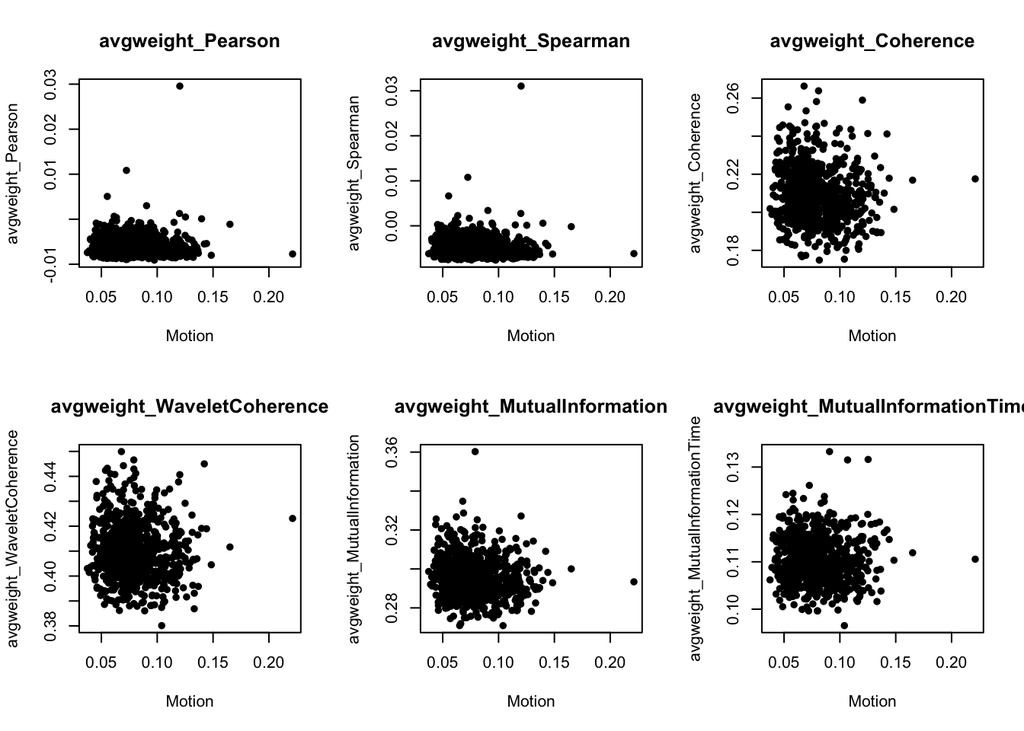

```r
#For each of the 6 metrics, plot the correlation between the average weight and motion
par(mfrow=c(2,3))

myPlot<-function(index) {
  plot(alldata[,index] ~ alldata$motion, main=names(alldata[index]),pch=16,xlab="Motion",ylab=names(alldata)[index])
       }
lapply(6:11,FUN=myPlot)
```

```r
#calculate the correlation between average weight and motion
formulaeAsText <- paste(names(alldata)[6:11], " ~ motion", sep="")
formulae <- lapply(formulaeAsText,FUN=formula)
rawcorr_avgweight<- lapply(formulae, function(eachFormula) {summary(lm(eachFormula,data=alldata))})
rawcorr_avgweight_sigmotion <- lapply(formulae, function(eachFormula) {summary(lm(eachFormula,data=alldata))$coefficients[2,4]})
rawmotioncorr <- data.frame(names(alldata)[6:11], unlist(rawcorr_avgweight_sigmotion))
rawmotioncorr
```

```
##              names.alldata..6.11. unlist.rawcorr_avgweight_sigmotion.
## 1               avgweight_Pearson                         0.849910349
## 2              avgweight_Spearman                         0.872579712
## 3             avgweight_Coherence                         0.008229948
## 4      avgweight_WaveletCoherence                         0.071982686
## 5     avgweight_MutualInformation                         0.010146754
## 6 avgweight_MutualInformationTime                         0.905910614
```

## Raw modularity and motion

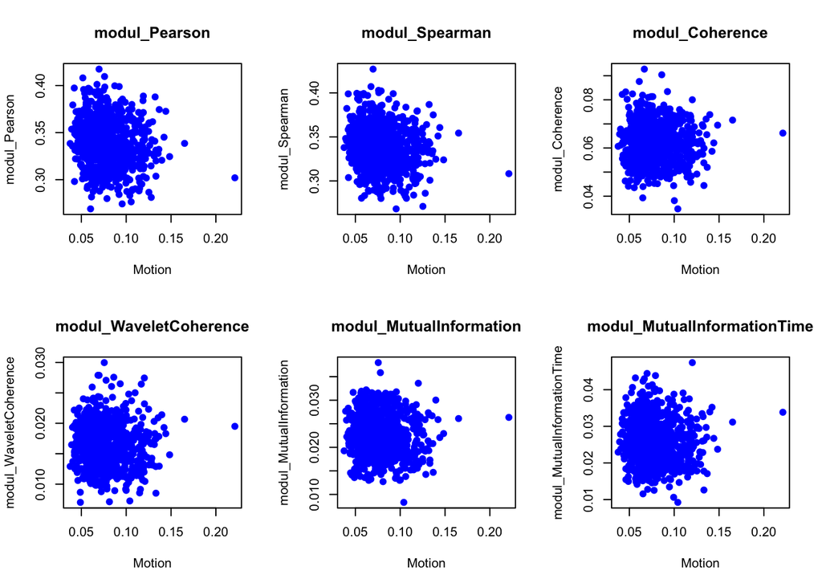

```r
#For each of the 6 metrics, plot the correlation between the raw modularity metrics calculated when tuning for 7 communities and motion
par(mfrow=c(2,3))

myPlot<-function(index) {
  plot(alldata[,index] ~ alldata$motion, main=names(alldata[index]),pch=19,xlab="Motion", col= "blue",ylab=names(alldata)[index])
       }
lapply(12:17,FUN=myPlot)
```

```r
#calculate the relationship between raw modularity and motion
formulaeAsText <- paste(names(alldata)[12:17], " ~ motion", sep="")
formulae <- lapply(formulaeAsText,FUN=formula)
rawcorr_modul<- lapply(formulae, function(eachFormula) {summary(lm(eachFormula,data=alldata))})
rawcorr_modul_sigmotion <- lapply(formulae, function(eachFormula) {summary(lm(eachFormula,data=alldata))$coefficients[2,4]})
rawmotionmodul_corr <- data.frame(names(alldata)[12:17], unlist(rawcorr_modul_sigmotion))
rawmotionmodul_corr
```

```
##         names.alldata..12.17. unlist.rawcorr_modul_sigmotion.
## 1               modul_Pearson                    1.872340e-06
## 2              modul_Spearman                    1.360329e-05
## 3             modul_Coherence                    2.620588e-01
## 4      modul_WaveletCoherence                    6.664649e-01
## 5     modul_MutualInformation                    1.450993e-01
## 6 modul_MutualInformationTime                    3.556846e-02
```

## Modularity and motion, controlling for avg weight

```r
#calculate the relationship between modularity and motion controlling for avg weight
formulaeAsText <- paste(names(alldata)[12:17], " ~ motion + avgweight_", unlist(strsplit(names(alldata)[12:17], "_"))[2*(1:length(names(alldata[,12:17])))], sep="")
formulae <- lapply(formulaeAsText,FUN=formula)
corr_modul<- lapply(formulae, function(eachFormula) {summary(lm(eachFormula,data=alldata))})
corr_modul_sigmotion <- lapply(formulae, function(eachFormula) {summary(lm(eachFormula,data=alldata))$coefficients[2,4]})
motionmodul_corr <- data.frame(names(alldata)[12:17], unlist(corr_modul_sigmotion))
motionmodul_corr
```

```
##         names.alldata..12.17. unlist.corr_modul_sigmotion.
## 1               modul_Pearson                 1.861559e-06
## 2              modul_Spearman                 1.388107e-05
## 3             modul_Coherence                 5.826322e-01
## 4      modul_WaveletCoherence                 8.593615e-01
## 5     modul_MutualInformation                 4.766839e-01
## 6 modul_MutualInformationTime                 3.522362e-02
```

## Modularity and motion, controlling for all covariates

```r
#calculate the relationship between modularity and motion controlling for avg weight
formulaeAsText <- paste(names(alldata)[12:17], " ~ motion + Age_numeric + Gender + avgweight_", unlist(strsplit(names(alldata)[12:17], "_"))[2*(1:length(names(alldata[,12:17])))], sep="")
formulae <- lapply(formulaeAsText,FUN=formula)
corr_covary_modul<- lapply(formulae, function(eachFormula) {summary(lm(eachFormula,data=alldata))})
corr_covary_modul_sigmotion <- lapply(formulae, function(eachFormula) {summary(lm(eachFormula,data=alldata))$coefficients[2,4]})
motionmodul_corr_covary <- data.frame(names(alldata)[12:17], unlist(corr_covary_modul_sigmotion))
motionmodul_corr_covary
```

```
##         names.alldata..12.17. unlist.corr_covary_modul_sigmotion.
## 1               modul_Pearson                        6.129998e-07
## 2              modul_Spearman                        4.213690e-06
## 3             modul_Coherence                        4.964666e-01
## 4      modul_WaveletCoherence                        9.406788e-01
## 5     modul_MutualInformation                        4.243238e-01
## 6 modul_MutualInformationTime                        2.011175e-02
```

## Is this affected by differences in number of communities detected across subjects and metrics?

Are the number of communities correlated with motion? And then, does the same pattern of sig relationships present if controlling for number of communities detected for each subject?

```r
#calculate the relationship between motion and number of communities detected
formulaeAsText <- paste(names(alldata)[18:23], " ~ motion + avgweight_",unlist(strsplit(names(alldata)[12:17], "_"))[2*(1:length(names(alldata[,12:17])))], sep="")
formulae <- lapply(formulaeAsText,FUN=formula)
corr_numcomms<- lapply(formulae, function(eachFormula) {summary(lm(eachFormula,data=alldata))})
corr_numcomms_sigmotion<- lapply(formulae, function(eachFormula) {summary(lm(eachFormula,data=alldata))$coefficients[2,4]})
numcomms_corr <- data.frame(names(alldata)[12:17], unlist(corr_numcomms_sigmotion))
numcomms_corr
```

```
##         names.alldata..12.17. unlist.corr_numcomms_sigmotion.
## 1               modul_Pearson                      0.12460153
## 2              modul_Spearman                      0.25910437
## 3             modul_Coherence                      0.29773048
## 4      modul_WaveletCoherence                      0.33349882
## 5     modul_MutualInformation                      0.67596439
## 6 modul_MutualInformationTime                      0.06435063
```

```r
#calculate the relationship between modularity and motion also controlling for the number of communities found for each subject
formulaeAsText <- paste(names(alldata)[12:17], " ~ motion + Age_numeric + Gender + avgweight_", unlist(strsplit(names(alldata)[12:17], "_"))[2*(1:length(names(alldata[,12:17])))], "+ num_communities_", unlist(strsplit(names(alldata)[12:17], "_"))[2*(1:length(names(alldata[,12:17])))], sep="")
formulae <- lapply(formulaeAsText,FUN=formula)
corr_covary2_modul<- lapply(formulae, function(eachFormula) {summary(lm(eachFormula,data=alldata))})
corr_covary2_modul_sigmotion <- lapply(formulae, function(eachFormula) {summary(lm(eachFormula,data=alldata))$coefficients[2,4]})
motionmodul_corr2_covary <- data.frame(names(alldata)[12:17], unlist(corr_covary2_modul_sigmotion))
motionmodul_corr2_covary
```

```
##         names.alldata..12.17. unlist.corr_covary2_modul_sigmotion.
## 1               modul_Pearson                         2.189365e-06
## 2              modul_Spearman                         8.945399e-06
## 3             modul_Coherence                         8.014740e-01
## 4      modul_WaveletCoherence                         4.792491e-01
## 5     modul_MutualInformation                         5.186341e-01
## 6 modul_MutualInformationTime                         1.690071e-01
```

# Run 2

## Avg weight and motion

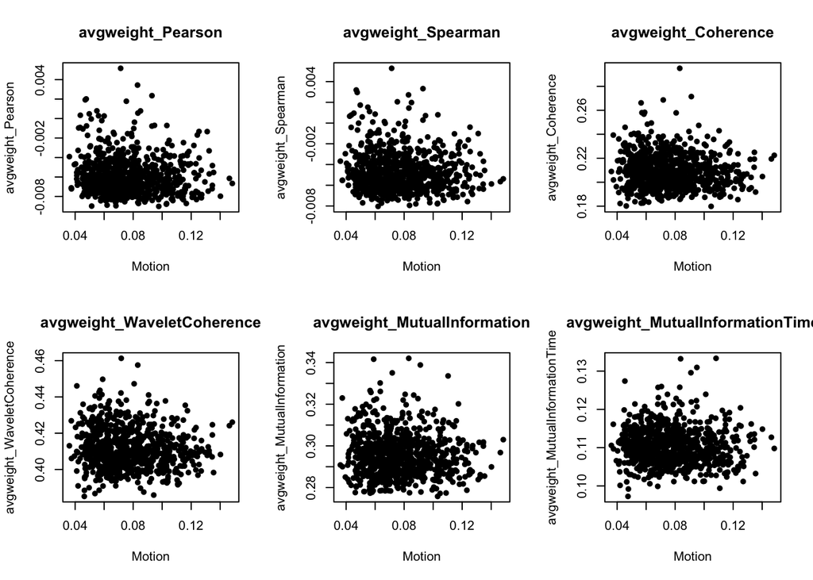

```r
#For each of the 6 metrics, plot the correlation between the average weight and motion
par(mfrow=c(2,3))

myPlot<-function(index) {
  plot(alldata[,index] ~ alldata$motion, main=names(alldata[index]),pch=16,xlab="Motion",ylab=names(alldata)[index])
       }
lapply(6:11,FUN=myPlot)
```

```r
#calculate the correlation between average weight and motion
formulaeAsText <- paste(names(alldata)[6:11], " ~ motion", sep="")
formulae <- lapply(formulaeAsText,FUN=formula)
rawcorr_avgweight<- lapply(formulae, function(eachFormula) {summary(lm(eachFormula,data=alldata))})
rawcorr_avgweight_sigmotion <- lapply(formulae, function(eachFormula) {summary(lm(eachFormula,data=alldata))$coefficients[2,4]})
rawmotioncorr <- data.frame(names(alldata)[6:11], unlist(rawcorr_avgweight_sigmotion))
rawmotioncorr
```

```
##              names.alldata..6.11. unlist.rawcorr_avgweight_sigmotion.
## 1               avgweight_Pearson                          0.05844356
## 2              avgweight_Spearman                          0.06632649
## 3             avgweight_Coherence                          0.01623029
## 4      avgweight_WaveletCoherence                          0.06314377
## 5     avgweight_MutualInformation                          0.08072526
## 6 avgweight_MutualInformationTime                          0.37700634
```

## Raw modularity and motion

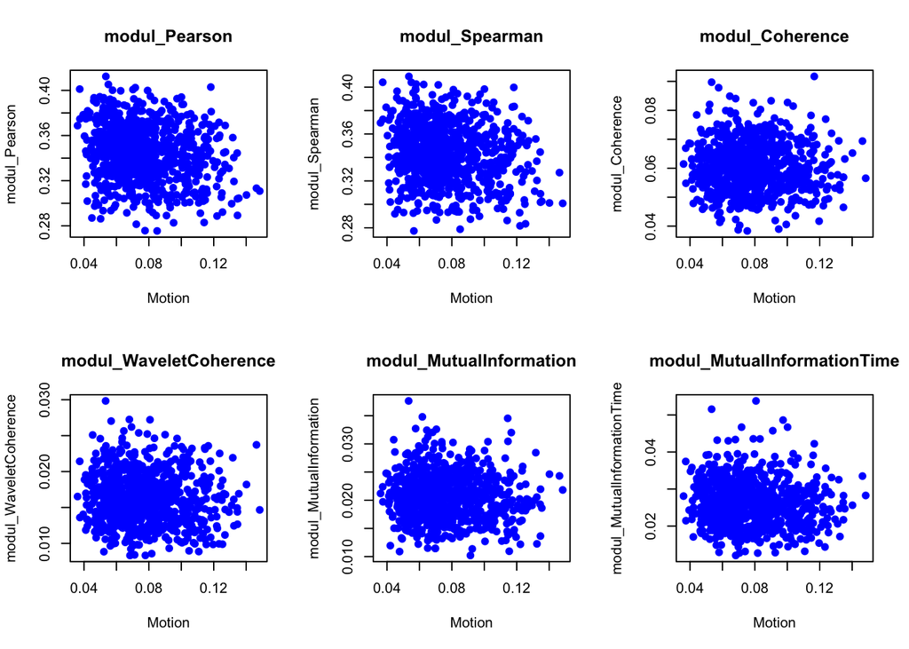

```r
#For each of the 6 metrics, plot the correlation between the raw modularity metrics calculated when tuning for 7 communities and motion
par(mfrow=c(2,3))
myPlot<-function(index) {
  plot(alldata[,index] ~ alldata$motion, main=names(alldata[index]),pch=19,xlab="Motion", col= "blue",ylab=names(alldata)[index])
       }
lapply(12:17,FUN=myPlot)
```

```r
#calculate the relationship between raw modularity and motion
formulaeAsText <- paste(names(alldata)[12:17], " ~ motion", sep="")
formulae <- lapply(formulaeAsText,FUN=formula)
rawcorr_modul<- lapply(formulae, function(eachFormula) {summary(lm(eachFormula,data=alldata))})
rawcorr_modul_sigmotion <- lapply(formulae, function(eachFormula) {summary(lm(eachFormula,data=alldata))$coefficients[2,4]})
rawmotionmodul_corr <- data.frame(names(alldata)[12:17], unlist(rawcorr_modul_sigmotion))
rawmotionmodul_corr
```

```
##         names.alldata..12.17. unlist.rawcorr_modul_sigmotion.
## 1               modul_Pearson                    4.226972e-08
## 2              modul_Spearman                    4.913442e-08
## 3             modul_Coherence                    5.270546e-01
## 4      modul_WaveletCoherence                    1.067238e-01
## 5     modul_MutualInformation                    8.554764e-02
## 6 modul_MutualInformationTime                    1.600619e-02
```

## Modularity and motion, controlling for avg weight

```r
#calculate the relationship between modularity and motion controlling for avg weight
formulaeAsText <- paste(names(alldata)[12:17], " ~ motion + avgweight_", unlist(strsplit(names(alldata)[12:17], "_"))[2*(1:length(names(alldata[,12:17])))], sep="")
formulae <- lapply(formulaeAsText,FUN=formula)
corr_modul<- lapply(formulae, function(eachFormula) {summary(lm(eachFormula,data=alldata))})
corr_modul_sigmotion <- lapply(formulae, function(eachFormula) {summary(lm(eachFormula,data=alldata))$coefficients[2,4]})
motionmodul_corr <- data.frame(names(alldata)[12:17], unlist(corr_modul_sigmotion))
motionmodul_corr
```

```
##         names.alldata..12.17. unlist.corr_modul_sigmotion.
## 1               modul_Pearson                 7.713473e-08
## 2              modul_Spearman                 1.181502e-07
## 3             modul_Coherence                 7.515240e-01
## 4      modul_WaveletCoherence                 2.689150e-01
## 5     modul_MutualInformation                 1.946692e-01
## 6 modul_MutualInformationTime                 2.026115e-02
```

## Modularity and motion, controlling for all covariates

```r
#calculate the relationship between modularity and motion controlling for avg weight
formulaeAsText <- paste(names(alldata)[12:17], " ~ motion + Age_numeric + Gender + avgweight_", unlist(strsplit(names(alldata)[12:17], "_"))[2*(1:length(names(alldata[,12:17])))], sep="")
formulae <- lapply(formulaeAsText,FUN=formula)
corr_covary_modul<- lapply(formulae, function(eachFormula) {summary(lm(eachFormula,data=alldata))})
corr_covary_modul_sigmotion <- lapply(formulae, function(eachFormula) {summary(lm(eachFormula,data=alldata))$coefficients[2,4]})
motionmodul_corr_covary <- data.frame(names(alldata)[12:17], unlist(corr_covary_modul_sigmotion))
motionmodul_corr_covary
```

```
##         names.alldata..12.17. unlist.corr_covary_modul_sigmotion.
## 1               modul_Pearson                        9.712232e-09
## 2              modul_Spearman                        1.250243e-08
## 3             modul_Coherence                        7.898168e-01
## 4      modul_WaveletCoherence                        2.342216e-01
## 5     modul_MutualInformation                        1.911603e-01
## 6 modul_MutualInformationTime                        1.164950e-02
```

## Is this affected by differences in number of communities detected across subjects and metrics?

Are the number of communities correlated with motion? And then, does the same pattern of sig relationships present if controlling for number of communities detected for each subject?

```r
#calculate the relationship between motion and number of communities detected
formulaeAsText <- paste(names(alldata)[18:23], " ~ motion + avgweight_",unlist(strsplit(names(alldata)[12:17], "_"))[2*(1:length(names(alldata[,12:17])))], sep="")
formulae <- lapply(formulaeAsText,FUN=formula)
corr_numcomms<- lapply(formulae, function(eachFormula) {summary(lm(eachFormula,data=alldata))})
corr_numcomms_sigmotion<- lapply(formulae, function(eachFormula) {summary(lm(eachFormula,data=alldata))$coefficients[2,4]})
numcomms_corr <- data.frame(names(alldata)[12:17], unlist(corr_numcomms_sigmotion))
numcomms_corr
```

```
##         names.alldata..12.17. unlist.corr_numcomms_sigmotion.
## 1               modul_Pearson                      0.41995309
## 2              modul_Spearman                      0.33602538
## 3             modul_Coherence                      0.28712654
## 4      modul_WaveletCoherence                      0.11264967
## 5     modul_MutualInformation                      0.11644835
## 6 modul_MutualInformationTime                      0.01024034
```

```r
#calculate the relationship between modularity and motion also controlling for the number of communities found for each subject
formulaeAsText <- paste(names(alldata)[12:17], " ~ motion + Age_numeric + Gender + avgweight_", unlist(strsplit(names(alldata)[12:17], "_"))[2*(1:length(names(alldata[,12:17])))], "+ num_communities_", unlist(strsplit(names(alldata)[12:17], "_"))[2*(1:length(names(alldata[,12:17])))], sep="")
formulae <- lapply(formulaeAsText,FUN=formula)
corr_covary2_modul<- lapply(formulae, function(eachFormula) {summary(lm(eachFormula,data=alldata))})
corr_covary2_modul_sigmotion <- lapply(formulae, function(eachFormula) {summary(lm(eachFormula,data=alldata))$coefficients[2,4]})
motionmodul_corr2_covary <- data.frame(names(alldata)[12:17], unlist(corr_covary2_modul_sigmotion))
motionmodul_corr2_covary
```

```
##         names.alldata..12.17. unlist.corr_covary2_modul_sigmotion.
## 1               modul_Pearson                         1.445636e-08
## 2              modul_Spearman                         2.115113e-08
## 3             modul_Coherence                         8.550852e-01
## 4      modul_WaveletCoherence                         5.966581e-01
## 5     modul_MutualInformation                         5.427756e-01
## 6 modul_MutualInformationTime                         1.950750e-01
```

# Run 3

## Avg weight and motion

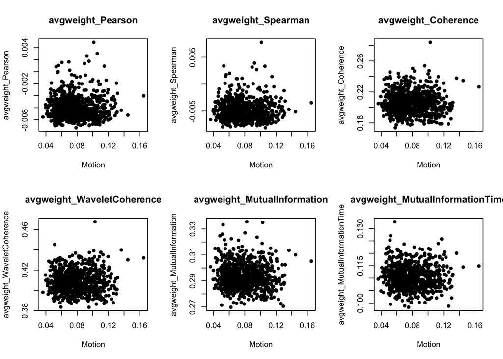

```r
#For each of the 6 metrics, plot the correlation between the average weight and motion
par(mfrow=c(2,3))

myPlot<-function(index) {
  plot(alldata[,index] ~ alldata$motion, main=names(alldata[index]),pch=16,xlab="Motion",ylab=names(alldata)[index])
       }
lapply(6:11,FUN=myPlot)
```

```r
#calculate the correlation between average weight and motion
formulaeAsText <- paste(names(alldata)[6:11], " ~ motion", sep="")
formulae <- lapply(formulaeAsText,FUN=formula)
rawcorr_avgweight<- lapply(formulae, function(eachFormula) {summary(lm(eachFormula,data=alldata))})
rawcorr_avgweight_sigmotion <- lapply(formulae, function(eachFormula) {summary(lm(eachFormula,data=alldata))$coefficients[2,4]})
rawmotioncorr <- data.frame(names(alldata)[6:11], unlist(rawcorr_avgweight_sigmotion))
rawmotioncorr
```

```
##              names.alldata..6.11. unlist.rawcorr_avgweight_sigmotion.
## 1               avgweight_Pearson                          0.75785223
## 2              avgweight_Spearman                          0.67309991
## 3             avgweight_Coherence                          0.53488951
## 4      avgweight_WaveletCoherence                          0.29686078
## 5     avgweight_MutualInformation                          0.09383867
## 6 avgweight_MutualInformationTime                          0.42353265
```

## Raw modularity and motion

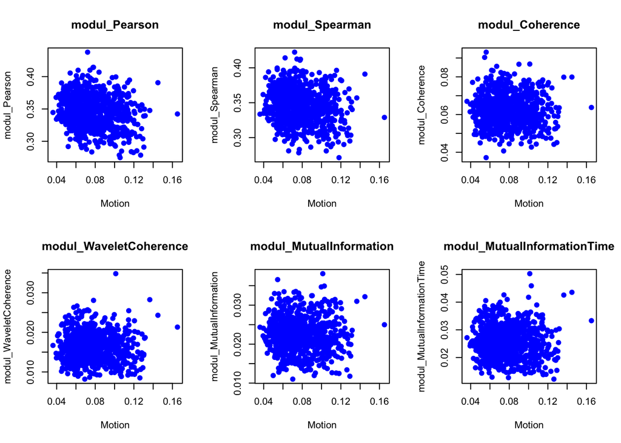

```r
#For each of the 6 metrics, plot the correlation between the raw modularity metrics calculated when tuning for 7 communities and motion
par(mfrow=c(2,3))
myPlot<-function(index) {
  plot(alldata[,index] ~ alldata$motion, main=names(alldata[index]),pch=19,xlab="Motion", col= "blue",ylab=names(alldata)[index])
       }
lapply(12:17,FUN=myPlot)
```

```r
#calculate the relationship between raw modularity and motion
formulaeAsText <- paste(names(alldata)[12:17], " ~ motion", sep="")
formulae <- lapply(formulaeAsText,FUN=formula)
rawcorr_modul<- lapply(formulae, function(eachFormula) {summary(lm(eachFormula,data=alldata))})
rawcorr_modul_sigmotion <- lapply(formulae, function(eachFormula) {summary(lm(eachFormula,data=alldata))$coefficients[2,4]})
rawmotionmodul_corr <- data.frame(names(alldata)[12:17], unlist(rawcorr_modul_sigmotion))
rawmotionmodul_corr
```

```
##         names.alldata..12.17. unlist.rawcorr_modul_sigmotion.
## 1               modul_Pearson                    7.003868e-08
## 2              modul_Spearman                    1.815363e-06
## 3             modul_Coherence                    2.131379e-01
## 4      modul_WaveletCoherence                    3.911724e-01
## 5     modul_MutualInformation                    5.818179e-01
## 6 modul_MutualInformationTime                    7.005731e-01
```

## Modularity and motion, controlling for avg weight

```r
#calculate the relationship between modularity and motion controlling for avg weight
formulaeAsText <- paste(names(alldata)[12:17], " ~ motion + avgweight_", unlist(strsplit(names(alldata)[12:17], "_"))[2*(1:length(names(alldata[,12:17])))], sep="")
formulae <- lapply(formulaeAsText,FUN=formula)
corr_modul<- lapply(formulae, function(eachFormula) {summary(lm(eachFormula,data=alldata))})
corr_modul_sigmotion <- lapply(formulae, function(eachFormula) {summary(lm(eachFormula,data=alldata))$coefficients[2,4]})
motionmodul_corr <- data.frame(names(alldata)[12:17], unlist(corr_modul_sigmotion))
motionmodul_corr
```

```
##         names.alldata..12.17. unlist.corr_modul_sigmotion.
## 1               modul_Pearson                 7.464745e-08
## 2              modul_Spearman                 1.963979e-06
## 3             modul_Coherence                 2.558381e-01
## 4      modul_WaveletCoherence                 1.879137e-01
## 5     modul_MutualInformation                 9.907375e-01
## 6 modul_MutualInformationTime                 8.329629e-01
```

## Modularity and motion, controlling for all covariates

```r
#calculate the relationship between modularity and motion controlling for avg weight
formulaeAsText <- paste(names(alldata)[12:17], " ~ motion + Age_numeric + Gender + avgweight_", unlist(strsplit(names(alldata)[12:17], "_"))[2*(1:length(names(alldata[,12:17])))], sep="")
formulae <- lapply(formulaeAsText,FUN=formula)
corr_covary_modul<- lapply(formulae, function(eachFormula) {summary(lm(eachFormula,data=alldata))})
corr_covary_modul_sigmotion <- lapply(formulae, function(eachFormula) {summary(lm(eachFormula,data=alldata))$coefficients[2,4]})
motionmodul_corr_covary <- data.frame(names(alldata)[12:17], unlist(corr_covary_modul_sigmotion))
motionmodul_corr_covary
```

```
##         names.alldata..12.17. unlist.corr_covary_modul_sigmotion.
## 1               modul_Pearson                        3.824848e-08
## 2              modul_Spearman                        1.156053e-06
## 3             modul_Coherence                        2.577944e-01
## 4      modul_WaveletCoherence                        1.611417e-01
## 5     modul_MutualInformation                        9.561524e-01
## 6 modul_MutualInformationTime                        7.588816e-01
```

## Is this affected by differences in number of communities detected across subjects and metrics?

Are the number of communities correlated with motion? And then, does the same pattern of sig relationships present if controlling for number of communities detected for each subject?

```r
#calculate the relationship between motion and number of communities detected
formulaeAsText <- paste(names(alldata)[18:23], " ~ motion + avgweight_",unlist(strsplit(names(alldata)[12:17], "_"))[2*(1:length(names(alldata[,12:17])))], sep="")
formulae <- lapply(formulaeAsText,FUN=formula)
corr_numcomms<- lapply(formulae, function(eachFormula) {summary(lm(eachFormula,data=alldata))})
corr_numcomms_sigmotion<- lapply(formulae, function(eachFormula) {summary(lm(eachFormula,data=alldata))$coefficients[2,4]})
numcomms_corr <- data.frame(names(alldata)[12:17], unlist(corr_numcomms_sigmotion))
numcomms_corr
```

```
##         names.alldata..12.17. unlist.corr_numcomms_sigmotion.
## 1               modul_Pearson                       0.3149307
## 2              modul_Spearman                       0.3011190
## 3             modul_Coherence                       0.5746235
## 4      modul_WaveletCoherence                       0.7825777
## 5     modul_MutualInformation                       0.8984163
## 6 modul_MutualInformationTime                       0.3677742
```

```r
#calculate the relationship between modularity and motion also controlling for the number of communities found for each subject
formulaeAsText <- paste(names(alldata)[12:17], " ~ motion + Age_numeric + Gender + avgweight_", unlist(strsplit(names(alldata)[12:17], "_"))[2*(1:length(names(alldata[,12:17])))], "+ num_communities_", unlist(strsplit(names(alldata)[12:17], "_"))[2*(1:length(names(alldata[,12:17])))], sep="")
formulae <- lapply(formulaeAsText,FUN=formula)
corr_covary2_modul<- lapply(formulae, function(eachFormula) {summary(lm(eachFormula,data=alldata))})
corr_covary2_modul_sigmotion <- lapply(formulae, function(eachFormula) {summary(lm(eachFormula,data=alldata))$coefficients[2,4]})
motionmodul_corr2_covary <- data.frame(names(alldata)[12:17], unlist(corr_covary2_modul_sigmotion))
motionmodul_corr2_covary
```

```
##         names.alldata..12.17. unlist.corr_covary2_modul_sigmotion.
## 1               modul_Pearson                         6.758814e-08
## 2              modul_Spearman                         1.651045e-07
## 3             modul_Coherence                         3.406826e-01
## 4      modul_WaveletCoherence                         1.088147e-01
## 5     modul_MutualInformation                         9.385934e-01
## 6 modul_MutualInformationTime                         8.118976e-01
```

# Run 4

## Avg weight and motion

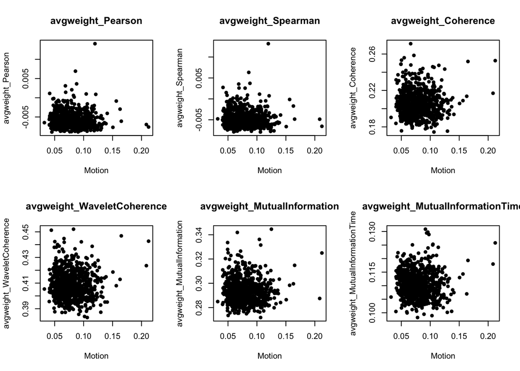

```r
#For each of the 6 metrics, plot the correlation between the average weight and motion
par(mfrow=c(2,3))

myPlot<-function(index) {
  plot(alldata[,index] ~ alldata$motion, main=names(alldata[index]),pch=16,xlab="Motion",ylab=names(alldata)[index])
       }
lapply(6:11,FUN=myPlot)
```

```r
#calculate the correlation between average weight and motion
formulaeAsText <- paste(names(alldata)[6:11], " ~ motion", sep="")
formulae <- lapply(formulaeAsText,FUN=formula)
rawcorr_avgweight<- lapply(formulae, function(eachFormula) {summary(lm(eachFormula,data=alldata))})
rawcorr_avgweight_sigmotion <- lapply(formulae, function(eachFormula) {summary(lm(eachFormula,data=alldata))$coefficients[2,4]})
rawmotioncorr <- data.frame(names(alldata)[6:11], unlist(rawcorr_avgweight_sigmotion))
rawmotioncorr
```

```
##              names.alldata..6.11. unlist.rawcorr_avgweight_sigmotion.
## 1               avgweight_Pearson                           0.4445279
## 2              avgweight_Spearman                           0.1443501
## 3             avgweight_Coherence                           0.8278173
## 4      avgweight_WaveletCoherence                           0.6140492
## 5     avgweight_MutualInformation                           0.8340470
## 6 avgweight_MutualInformationTime                           0.9763117
```

## Raw modularity and motion

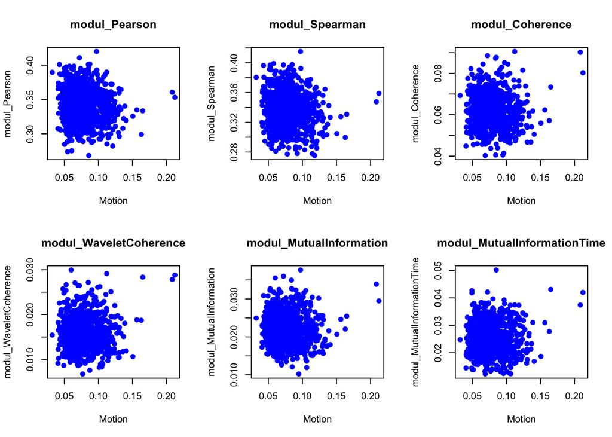

```r
#For each of the 6 metrics, plot the correlation between the raw modularity metrics calculated when tuning for 7 communities and motion
par(mfrow=c(2,3))
myPlot<-function(index) {
  plot(alldata[,index] ~ alldata$motion, main=names(alldata[index]),pch=19,xlab="Motion", col= "blue",ylab=names(alldata)[index])
       }
lapply(12:17,FUN=myPlot)
```

```r
#calculate the relationship between raw modularity and motion
formulaeAsText <- paste(names(alldata)[12:17], " ~ motion", sep="")
formulae <- lapply(formulaeAsText,FUN=formula)
rawcorr_modul<- lapply(formulae, function(eachFormula) {summary(lm(eachFormula,data=alldata))})
rawcorr_modul_sigmotion <- lapply(formulae, function(eachFormula) {summary(lm(eachFormula,data=alldata))$coefficients[2,4]})
rawmotionmodul_corr <- data.frame(names(alldata)[12:17], unlist(rawcorr_modul_sigmotion))
rawmotionmodul_corr
```

```
##         names.alldata..12.17. unlist.rawcorr_modul_sigmotion.
## 1               modul_Pearson                    0.0001512957
## 2              modul_Spearman                    0.0001971462
## 3             modul_Coherence                    0.2955949940
## 4      modul_WaveletCoherence                    0.3408461294
## 5     modul_MutualInformation                    0.1376044417
## 6 modul_MutualInformationTime                    0.8711035053
```

## Modularity and motion, controlling for avg weight

```r
#calculate the relationship between modularity and motion controlling for avg weight
formulaeAsText <- paste(names(alldata)[12:17], " ~ motion + avgweight_", unlist(strsplit(names(alldata)[12:17], "_"))[2*(1:length(names(alldata[,12:17])))], sep="")
formulae <- lapply(formulaeAsText,FUN=formula)
corr_modul<- lapply(formulae, function(eachFormula) {summary(lm(eachFormula,data=alldata))})
corr_modul_sigmotion <- lapply(formulae, function(eachFormula) {summary(lm(eachFormula,data=alldata))$coefficients[2,4]})
motionmodul_corr <- data.frame(names(alldata)[12:17], unlist(corr_modul_sigmotion))
motionmodul_corr
```

```
##         names.alldata..12.17. unlist.corr_modul_sigmotion.
## 1               modul_Pearson                 0.0001207717
## 2              modul_Spearman                 0.0001902612
## 3             modul_Coherence                 0.2655642248
## 4      modul_WaveletCoherence                 0.4052527343
## 5     modul_MutualInformation                 0.1379327856
## 6 modul_MutualInformationTime                 0.8665059577
```

## Modularity and motion, controlling for all covariates

```r
#calculate the relationship between modularity and motion controlling for avg weight
formulaeAsText <- paste(names(alldata)[12:17], " ~ motion + Age_numeric + Gender + avgweight_", unlist(strsplit(names(alldata)[12:17], "_"))[2*(1:length(names(alldata[,12:17])))], sep="")
formulae <- lapply(formulaeAsText,FUN=formula)
corr_covary_modul<- lapply(formulae, function(eachFormula) {summary(lm(eachFormula,data=alldata))})
corr_covary_modul_sigmotion <- lapply(formulae, function(eachFormula) {summary(lm(eachFormula,data=alldata))$coefficients[2,4]})
motionmodul_corr_covary <- data.frame(names(alldata)[12:17], unlist(corr_covary_modul_sigmotion))
motionmodul_corr_covary
```

```
##         names.alldata..12.17. unlist.corr_covary_modul_sigmotion.
## 1               modul_Pearson                        7.622727e-05
## 2              modul_Spearman                        1.387891e-04
## 3             modul_Coherence                        3.216094e-01
## 4      modul_WaveletCoherence                        3.900668e-01
## 5     modul_MutualInformation                        1.746228e-01
## 6 modul_MutualInformationTime                        8.827260e-01
```

## Is this affected by differences in number of communities detected across subjects and metrics?

Are the number of communities correlated with motion? And then, does the same pattern of sig relationships present if controlling for number of communities detected for each subject?

```r
#calculate the relationship between motion and number of communities detected
formulaeAsText <- paste(names(alldata)[18:23], " ~ motion + avgweight_",unlist(strsplit(names(alldata)[12:17], "_"))[2*(1:length(names(alldata[,12:17])))], sep="")
formulae <- lapply(formulaeAsText,FUN=formula)
corr_numcomms<- lapply(formulae, function(eachFormula) {summary(lm(eachFormula,data=alldata))})
corr_numcomms_sigmotion<- lapply(formulae, function(eachFormula) {summary(lm(eachFormula,data=alldata))$coefficients[2,4]})
numcomms_corr <- data.frame(names(alldata)[12:17], unlist(corr_numcomms_sigmotion))

#calculate the relationship between modularity and motion also controlling for the number of communities found for each subject
formulaeAsText <- paste(names(alldata)[12:17], " ~ motion + Age_numeric + Gender + avgweight_", unlist(strsplit(names(alldata)[12:17], "_"))[2*(1:length(names(alldata[,12:17])))], "+ num_communities_", unlist(strsplit(names(alldata)[12:17], "_"))[2*(1:length(names(alldata[,12:17])))], sep="")
formulae <- lapply(formulaeAsText,FUN=formula)
corr_covary2_modul<- lapply(formulae, function(eachFormula) {summary(lm(eachFormula,data=alldata))})
corr_covary2_modul_sigmotion <- lapply(formulae, function(eachFormula) {summary(lm(eachFormula,data=alldata))$coefficients[2,4]})
motionmodul_corr2_covary <- data.frame(names(alldata)[12:17], unlist(corr_covary2_modul_sigmotion))
motionmodul_corr2_covary
```

```
##         names.alldata..12.17. unlist.corr_covary2_modul_sigmotion.
## 1               modul_Pearson                         0.0001632477
## 2              modul_Spearman                         0.0003838211
## 3             modul_Coherence                         0.4370572337
## 4      modul_WaveletCoherence                         0.2367454173
## 5     modul_MutualInformation                         0.0978196612
## 6 modul_MutualInformationTime                         0.9766546851
```